# carlos_esteban_posada_AG2

Actividad Guiada 2 del curso: Algoritmos de optimización

**Nombre**: Carlos Esteban Posada  
**URL**: https://colab.research.google.com/drive/1hESA5X-TeFVtTEO9NyGfugsqYg_Ujs-I?usp=sharing

**URL GIT**: https://github.com/cposada8/03MAIR-Algoritmos-de-Optimizacion-CEPM/blob/main/carlos_esteban_posada_AG2.ipynb

```python
import math
import numpy as np
import itertools
from time import time
import matplotlib.pyplot as plt
```

## Viaje por el río

```python
tarifas = [
[0,5,4,3,999,999,999],   #desde nodo 0
[999,0,999,2,3,999,11],  #desde nodo 1
[999,999, 0,1,999,4,10], #desde nodo 2
[999,999,999, 0,5,6,9],
[999,999, 999,999,0,999,4],
[999,999, 999,999,999,0,3],
[999,999,999,999,999,999,0]
]
```

```python
hijos = [
[1, 2, 3], # hijos del nodo 0
[3, 4, 6], # hijos del nodo 1
[3, 5, 6], # hijos del nodo 2
[4, 5, 6],
[6],
[6],
[]
]
```

```python
# función para generar el grafo inverso.
# se recorre el grafo original y se buscan los padres
def padres_de(grafo):
  # se inicializa el grafo de padres (el inverso de hijos) todo con listas vacías
  # es decir por ahora nadie tiene padre
  padres = [[] for i in range(len(hijos))]

  for padre in range(len(grafo)): # cada línea es un nodo
    for hijo in grafo[padre]:
      padres[hijo].append(padre)
  return padres
```

```python
# generación del grafo de padres (grafo inverso)
padres = padres_de(hijos)
padres
```

```
[[], [0], [0], [0, 1, 2], [1, 3], [2, 3], [1, 2, 3, 4, 5]]
```

```python
origen = 0
objetivo = 6
```

```python
# se inicializan los vectores que se usarán durantes las iteraciones del algoritmo
distancias = [np.inf for x in range(len(hijos))] # vector de distancias desde cada nodo hasta el nodo objetivo
visitados = set() # todos nodos que están perfectamente visitados
rutas = [[] for x in range(len(hijos))] # representa el nodo óptimo al que se puede viajar desde el nodo dado
print(distancias)
print(visitados)
print(rutas)
```

```
[inf, inf, inf, inf, inf, inf, inf]
set()
[[], [], [], [], [], [], []]
```

```python
# inicio visitando al nodo objetivo
distancias[objetivo] = 0
visitados.add(objetivo)
```

```python
# algoritmo de atrás hacia adelante
queue = [] # cola para ir recorriendo los nodos desde el final

# agregar los padres del objetivo
for padre in padres[objetivo]:
  queue.append(padre)

# inicio del llenado de las distancias:
while (queue) and (origen not in visitados):
  # print("cola actual:",queue)
  elemento = queue.pop(0)
  # print("elemento", elemento)

  # primero se verifica que el elemento no haya sido visitado ya:
  if elemento in visitados:
    continue

  # verificar que el elemento no tenga hijos sin visitar
  # si los tiene, se manda el elemento para el final de la lista
  hijos_visitados = set(hijos[elemento]).intersection(visitados)
  # print("hijos visitados", hijos_visitados)
  if len(hijos[elemento]) != len(hijos_visitados):
    # print(elemento, hijos[elemento], "tiene sin visitar")
    queue.append(elemento)
    pass
  else: # todos sus hijos están visitados

    # se encuentra la distancia del elemento al objetivo pasando por cada hijo
    distancias_nodo = {}
    for hijo in hijos[elemento]:
      distancias_nodo[hijo] = distancias[hijo] + tarifas[elemento][hijo]
    min_distancia = min(distancias_nodo.values())
    # print("mindistancia", min_distancia)

    # se agregan la distancia del elemento al nodo objetivo, los visitados a la
    # lista de visitados y se agregan las rutas óptimas desde el elemento
    # hasta el objetivo
    distancias[elemento] = min_distancia
    visitados.add(elemento)
    # enlistar todos los elementos de distancia minima
    posibles_rutas = [key for key, val in distancias_nodo.items() if val == min_distancia]
    # print("posibles_rutas", posibles_rutas)
    rutas[elemento] = posibles_rutas

    # finalmente se agregan los padres del elemento a la cola
    for padre in padres[elemento]:
      queue.append(padre)

  # print()
```

```python
print("posibles rutas óptimas:", posibles_rutas)
```

```
posibles rutas óptimas: [2]
```

```python
# imprimir una ruta óptima
ruta_optima = [origen]
visitado = origen
while (visitado != objetivo):
  siguiente = rutas[visitado][0]
  ruta_optima.append(siguiente)
  visitado = siguiente
print("Una ruta óptima es:", ruta_optima)
print("con un costo total de:", distancias[origen])
```

```
Una ruta óptima es: [0, 2, 5, 6]
con un costo total de: 11
```

## Problema de Asignacion de tarea

```python
COSTES=[[11,12,18,40],
        [14,15,13,22],
        [11,17,19,23],
        [17,14,20,28]]
```

```python
def valor(S,COSTES):
  VALOR = 0
  for i in range(len(S)):
    VALOR += COSTES[S[i]][i]
  return VALOR
valor((1, 2, 0, 3),COSTES)
```

```
77
```

```python
#Coste inferior para soluciones parciales
#  (1,3,) Se asigna la tarea 1 al agente 0 y la tarea 3 al agente 1

def CI(S,COSTES):
  VALOR = 0
  #Valores establecidos
  for i in range(len(S)):
    VALOR += COSTES[i][S[i]]

  #Estimacion
  for i in range( len(S), len(COSTES)   ):
    VALOR += min( [ COSTES[j][i] for j in range(len(S), len(COSTES))  ])
  return VALOR

def CS(S,COSTES):
  VALOR = 0
  #Valores establecidos
  for i in range(len(S)):
    VALOR += COSTES[i][S[i]]

  #Estimacion
  for i in range( len(S), len(COSTES)   ):
    VALOR += max( [ COSTES[j][i] for j in range(len(S), len(COSTES))  ])
  return VALOR
```

```python
#Genera tantos hijos como como posibilidades haya para la siguiente elemento de la tupla
#(0,) -> (0,1), (0,2), (0,3)
def crear_hijos(NODO, N):
  HIJOS = []
  for i in range(N ):
    if i not in NODO:
      HIJOS.append({'s':NODO +(i,)    })
  return HIJOS
```

```python
def ramificacion_y_poda(COSTES):
#Construccion iterativa de soluciones(arbol). En cada etapa asignamos un agente(ramas).
#Nodos del grafo  { s:(1,2),CI:3,CS:5  }
  #print(COSTES)
  DIMENSION = len(COSTES)
  MEJOR_SOLUCION=tuple( i for i in range(len(COSTES)) )
  CotaSup = valor(MEJOR_SOLUCION,COSTES)
  #print("Cota Superior:", CotaSup)

  NODOS=[]
  NODOS.append({'s':(), 'ci':CI((),COSTES)    } )

  iteracion = 0

  while( len(NODOS) > 0):
    iteracion +=1
    nodo_prometedor = [ min(NODOS, key=lambda x:x['ci']) ][0]['s']
    #print("Nodo prometedor:", nodo_prometedor)
    #Ramificacion
    #Se generan los hijos
    HIJOS =[ {'s':x['s'], 'ci':CI(x['s'], COSTES)   } for x in crear_hijos(nodo_prometedor, DIMENSION) ]

    #Revisamos la cota superior y nos quedamos con la mejor solucion si llegamos a una solucion final
    NODO_FINAL = [x for x in HIJOS if len(x['s']) == DIMENSION  ]
    if len(NODO_FINAL ) >0:
      #print("\n********Soluciones:",  [x for x in HIJOS if len(x['s']) == DIMENSION  ] )
      if NODO_FINAL[0]['ci'] < CotaSup:
        CotaSup = NODO_FINAL[0]['ci']
        MEJOR_SOLUCION = NODO_FINAL

    #Poda
    HIJOS = [x for x in HIJOS if x['ci'] < CotaSup   ]

    #Añadimos los hijos
    NODOS.extend(HIJOS)

    #Eliminamos el nodo ramificado
    NODOS =  [  x for x in NODOS if x['s'] != nodo_prometedor    ]

  print("La solucion final es:" ,MEJOR_SOLUCION , " en " , iteracion , " iteraciones" , " para dimension: " ,DIMENSION  )



ramificacion_y_poda(COSTES)
```

```
La solucion final es: [{'s': (1, 2, 0, 3), 'ci': 64}]  en  10  iteraciones  para dimension:  4
```

### Análisis adicional (Mejorar nota)

- ¿Qué complejidad tiene el algoritmo por fuerza bruta?
- Generar matrices con valores aleatorios de mayores dimensiones (5, 6, 7, ...) y ejecutar ambos algoritmos.
  - ¿A partir de qué dimensión el algoritmo por fuerza bruta deja de ser una opción?
  - ¿Hay algún valor de la dimensión a partir de la cual el algoritmo de ramificación y poda deja de ser una opción válida?

El algoritmo por fuerza bruta tendrá un orden de complejidad n! pues deberá comprobar todas las posibles permutaciones de los índices de un array de tamaño n.

#### Implementación del método por fuerza bruta

```python
def costo_solucion(S,COSTES):
  VALOR = 0
  #Valores establecidos
  for i in range(len(S)):
    VALOR += COSTES[S[i]][i]
  return VALOR

def asignacion_tareas_fuerza_bruta(costes):
  n = len(costes)
  min_cost = np.inf
  sol_opt = None
  # obtengo todas las permutaciones posibles
  permutations = itertools.permutations(range(n))
  for option in permutations:
    costo_actual = costo_solucion(option, costes)
    if costo_actual < min_cost:
      min_cost = costo_actual
      sol_opt = option
  return sol_opt
```

```python
print(asignacion_tareas_fuerza_bruta(COSTES))
costo_solucion(asignacion_tareas_fuerza_bruta(COSTES), COSTES)
```

```
(0, 3, 1, 2)
```

```
61
```

#### Comparación ramificación y poda vs fuerza bruta

```python
max_coste =50
dimensiones = [2, 3, 4, 5, 6, 7, 8, 9, 10]
matrices_aleatorias = {dimension:np.random.randint(max_coste, size=(dimension, dimension)) for dimension in dimensiones}
```

```python
# ejecutando método de ramificación y poda
tiempos_ramif_poda = []
for dimension in dimensiones:
  print("dimension:", dimension)
  # ejecutar el algoritmo de ramificación y poda
  t_start = time()
  ramificacion_y_poda(matrices_aleatorias[dimension])
  t_end = time()-t_start
  print(t_end)
  tiempos_ramif_poda.append(t_end)
```

```
dimension: 2
La solucion final es: (0, 1)  en  1  iteraciones  para dimension:  2
0.001697540283203125
dimension: 3
La solucion final es: [{'s': (0, 2, 1), 'ci': 15}]  en  4  iteraciones  para dimension:  3
0.0014483928680419922
dimension: 4
La solucion final es: (0, 1, 2, 3)  en  5  iteraciones  para dimension:  4
0.00037169456481933594
dimension: 5
La solucion final es: [{'s': (2, 4, 3, 0, 1), 'ci': 84}]  en  37  iteraciones  para dimension:  5
0.0016393661499023438
dimension: 6
La solucion final es: [{'s': (3, 0, 2, 5, 4, 1), 'ci': 31}]  en  114  iteraciones  para dimension:  6
0.0046536922454833984
dimension: 7
La solucion final es: [{'s': (2, 3, 1, 5, 0, 4, 6), 'ci': 74}]  en  145  iteraciones  para dimension:  7
0.009642601013183594
dimension: 8
La solucion final es: [{'s': (7, 3, 1, 0, 2, 6, 4, 5), 'ci': 42}]  en  5404  iteraciones  para dimension:  8
2.681424140930176
dimension: 9
La solucion final es: [{'s': (4, 5, 3, 8, 6, 0, 7, 1, 2), 'ci': 64}]  en  1836  iteraciones  para dimension:  9
0.3778538703918457
dimension: 10
La solucion final es: [{'s': (3, 4, 5, 9, 6, 8, 2, 7, 1, 0), 'ci': 77}]  en  18693  iteraciones  para dimension:  10
39.892725706100464
```

```python
# ejecutando método de fuerza bruta
tiempos_fuerza_bruta = []
for dimension in dimensiones:
  print("dimension:", dimension)
  # ejecutar el algoritmo de ramificación y poda
  t_start = time()
  asignacion_tareas_fuerza_bruta(matrices_aleatorias[dimension])
  t_end = time()-t_start
  print(t_end)
  tiempos_fuerza_bruta.append(t_end)
```

```
dimension: 2
8.749961853027344e-05
dimension: 3
6.747245788574219e-05
dimension: 4
0.00013399124145507812
dimension: 5
0.0006535053253173828
dimension: 6
0.002458333969116211
dimension: 7
0.02022695541381836
dimension: 8
0.18480420112609863
dimension: 9
1.7972385883331299
dimension: 10
19.158466815948486
```

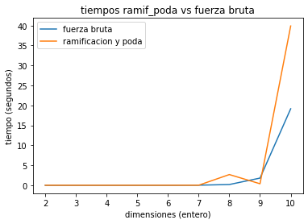

```python
# comparación tiempos
plt.plot(dimensiones, tiempos_fuerza_bruta, label="fuerza bruta")
plt.plot(dimensiones, tiempos_ramif_poda, label="ramificacion y poda")
plt.legend()
plt.title("tiempos ramif_poda vs fuerza bruta")
plt.xlabel("dimensiones (entero)")
plt.ylabel("tiempo (segundos)")
plt.show()
```

#### ¿Hay alguna dimensión para la cual el algoritmo de ramificación y poda deja de ser opción?

```python
max_coste =50
dimensiones = [2, 3, 4, 5, 6, 7, 8, 9, 10, 11]
matrices_aleatorias = {dimension:np.random.randint(max_coste, size=(dimension, dimension)) for dimension in dimensiones}
# ejecutando método de ramificación y poda
tiempos_ramif_poda = []
for dimension in dimensiones:
  print("dimension:", dimension)
  # ejecutar el algoritmo de ramificación y poda
  t_start = time()
  ramificacion_y_poda(matrices_aleatorias[dimension])
  t_end = time()-t_start
  print(t_end)
  tiempos_ramif_poda.append(t_end)
```

```
dimension: 2
La solucion final es: (0, 1)  en  1  iteraciones  para dimension:  2
0.00028133392333984375
dimension: 3
La solucion final es: (0, 1, 2)  en  1  iteraciones  para dimension:  3
0.0002751350402832031
dimension: 4
La solucion final es: [{'s': (0, 1, 3, 2), 'ci': 87}]  en  17  iteraciones  para dimension:  4
0.0009584426879882812
dimension: 5
La solucion final es: [{'s': (0, 2, 3, 1, 4), 'ci': 68}]  en  43  iteraciones  para dimension:  5
0.0013470649719238281
dimension: 6
La solucion final es: [{'s': (3, 2, 4, 5, 0, 1), 'ci': 29}]  en  151  iteraciones  para dimension:  6
0.01044464111328125
dimension: 7
La solucion final es: [{'s': (3, 4, 6, 0, 5, 2, 1), 'ci': 78}]  en  720  iteraciones  para dimension:  7
0.07729005813598633
dimension: 8
La solucion final es: [{'s': (3, 5, 4, 7, 0, 1, 2, 6), 'ci': 69}]  en  174  iteraciones  para dimension:  8
0.0184938907623291
dimension: 9
La solucion final es: [{'s': (1, 5, 6, 2, 4, 0, 7, 3, 8), 'ci': 57}]  en  367  iteraciones  para dimension:  9
0.050852060317993164
dimension: 10
La solucion final es: [{'s': (6, 2, 4, 9, 0, 5, 8, 3, 1, 7), 'ci': 62}]  en  6390  iteraciones  para dimension:  10
4.448698282241821
dimension: 11
La solucion final es: [{'s': (6, 5, 2, 7, 3, 4, 0, 10, 1, 9, 8), 'ci': 51}]  en  24863  iteraciones  para dimension:  11
87.59654641151428
```

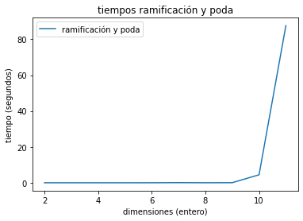

```python
# gráfica tiempos
plt.plot(dimensiones, tiempos_ramif_poda, label="ramificación y poda")
plt.legend()
plt.title("tiempos ramificación y poda")
plt.xlabel("dimensiones (entero)")
plt.ylabel("tiempo (segundos)")
plt.show()
```

Como se puede observar, desde la dimensión 11 en adelante el algoritmo empezará a ser inviable. Su naturaleza al ser exponencial dicta que habrá puntos donde ya no será una opción revisar este tipo de algoritmos.